# Hurricanes and Climate Change: A Bayesian approach

#### By: Madeline Abbott, Aidan Teppema, Daisy Cho

#### December 17, 2017

## Why Hurricanes?

In the past summer, there were two major and devastating category 4 hurricanes in the US. People in Central America, Texas, Louisiana and other states lost their shelter and loved ones from Hurricane. Hurricane Irma soon after attacked as a ruining the coast of Florida. We wanted to see if this was indicative of the future. Because of the severity of the destruction from the category 4 hurricanes we are looking at the average wind speed of hurricanes. Then, because of how quickly Hurricane Irma came after Hurricane Harvey, we decided to look at the frequency to see how many time we should expect hurricanes per year. Finally, we are looking at the average durations of the hurricanes. For example, Hurricane Harvey lasted for 17 days and we wanted to see if the durations of these devastations can be modeled. Looking at the wind speed, frequency, and durations of past hurricanes, we may be able to predict future hurricanes and be more prepared for them.

## The Datasets

To measure climate changes, we looked at four different data sets. The first data set is our main data set on hurricanes, provided by the homeland infrastructure foundation level data committee. This dataset recorded the hurricane’s wind speed, dates of occurrence, location, pressure, and the category of the hurricane. Our indicator variables are temperature anomalies provided by NASA, CO2 provided by the national oceanic and atmospheric administration, and the North Atlantic Oscillation Index or NAOI which is provided by the national center for atmospheric research.

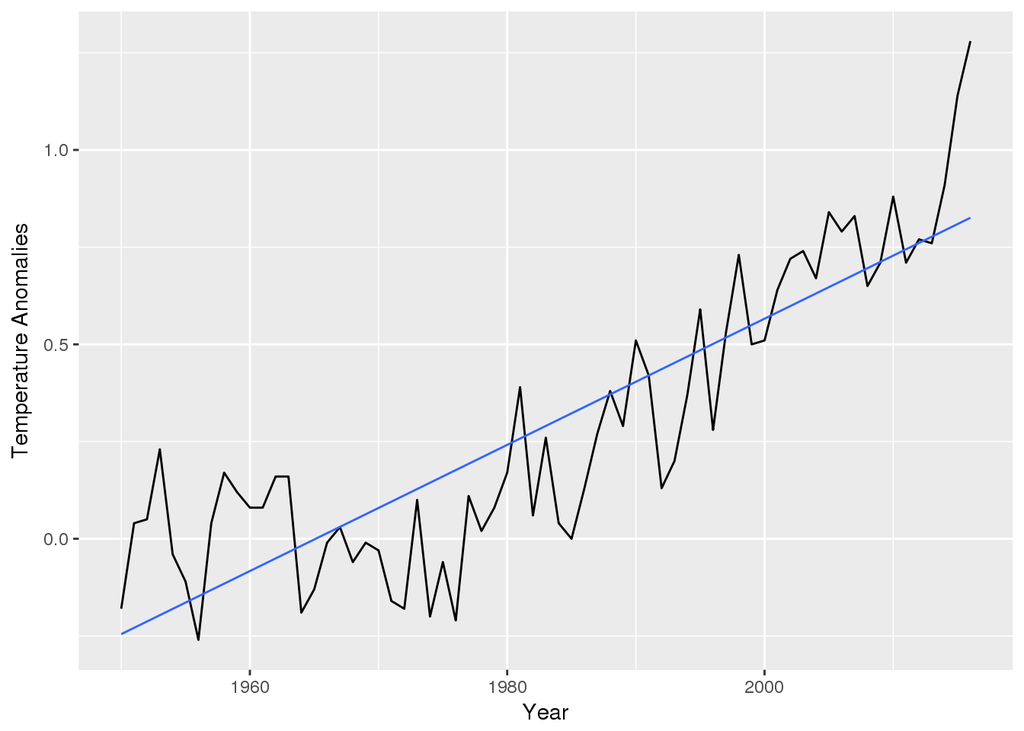

The temperature anomalies are the difference from the temperature at the time from the baseline temperature, which is created from an average of 30 years of temperature data. We used temperatures because absolute temperatures, or actual temperatures measured in current time is more prone to extraneous variables such as the temperature measurement tower, whereas temperature anomaly are not as affected by these extraneous variables.

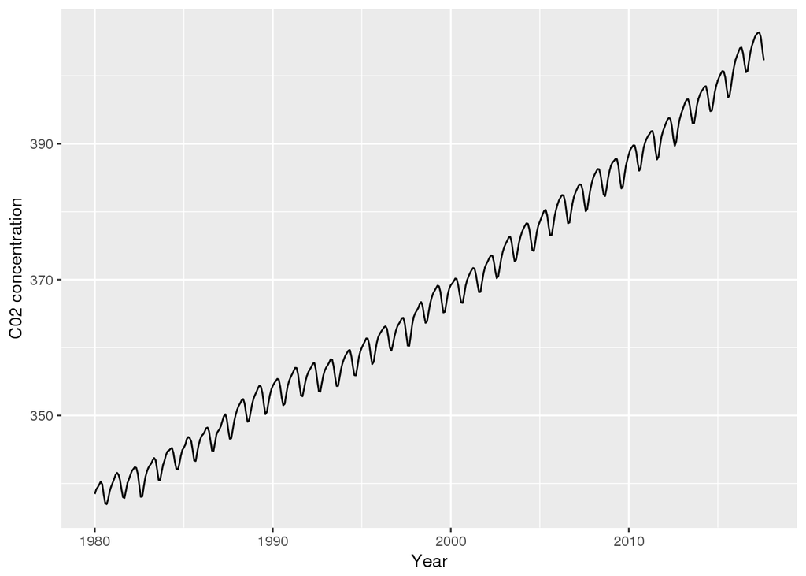

CO2 also shows an increasing throughout the years. CO2 concentration showed fluctuation throughout the years because when plants are growing, photosynthesis outweighs respiration. As a result, plants take more CO2 out of the atmosphere during the warm months when they are growing the most. This can lead to noticeably lower CO2 concentrations in the atmosphere. Respiration occurs all the time, but dominates during the colder months of the year, resulting in higher CO2 levels in the atmosphere during those months.`

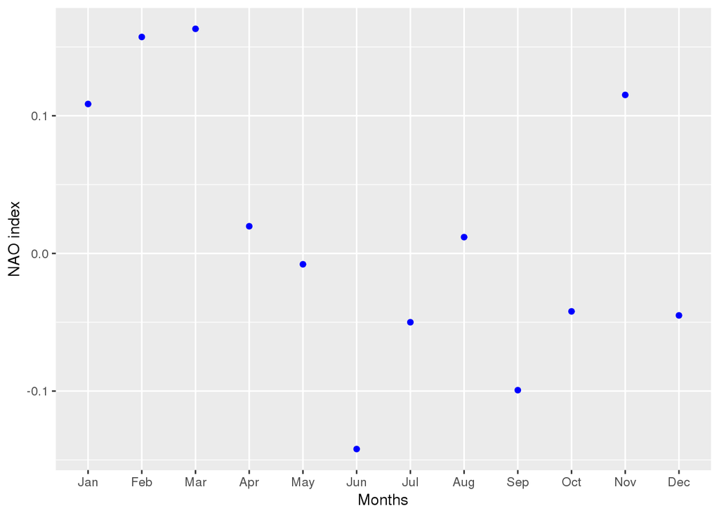

NAOI is the fluctuations in the difference of atmospheric pressure at sea level (SLP) in the Northern Atlantic ocean. High levels influences the rise of sea levels and the direction of tropical storm cyclones

## What is a Markov Chain?

For all our models we ran Markov chains in order to simulate the posterior results after running our models in rjags. A Markov chain is an approximation of values using our prior understanding of the quantity or relationship and the provided dataset. It is used to generate a sequence of values just from the value prior to it.

## Creating Our Models

In order to answer four different research questions, we decided to use two different Bayesian modeling: A normal-normal model and Poisson regression model. A normal-normal model assumes a normal distribution, or a “bell curve”, which the density curve described by its mean and standard deviation, for both the prior and the posterior. A Poisson regression model, uses a Poisson distribution, which expresses the probability of a given number of events occurring in a fixed interval of time if these events occur with a known constant rate, and assumes that the log of the expect value or also mean can be modeled by unknown parameters.

### Hurricane Wind speed

We first modeled the hurricane wind speed through time to see if there were any obvious trends throughout the years.

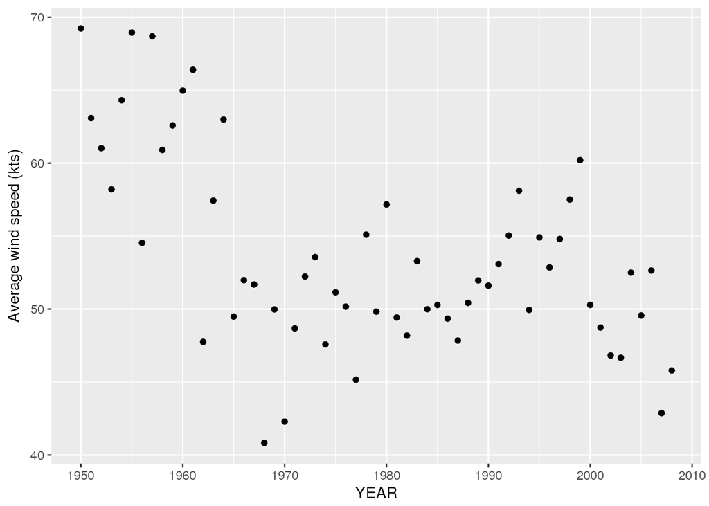

We used a normal-normal model to attempt to model wind speed with CO2 and NAO over time. The normal-normal model is called that because both the prior and posterior distributions of the data are normally distributed. All of the priors for this model are vague because, prior to creating and running our models, we didn’t know much about the impact of NAO or CO2 on hurricane wind speed.

### Hurricane Frequency

Based on the past summer of hurricanes, it seems as if hurricanes are occurring more and more frequently. We plotted our data to see if it agreed:

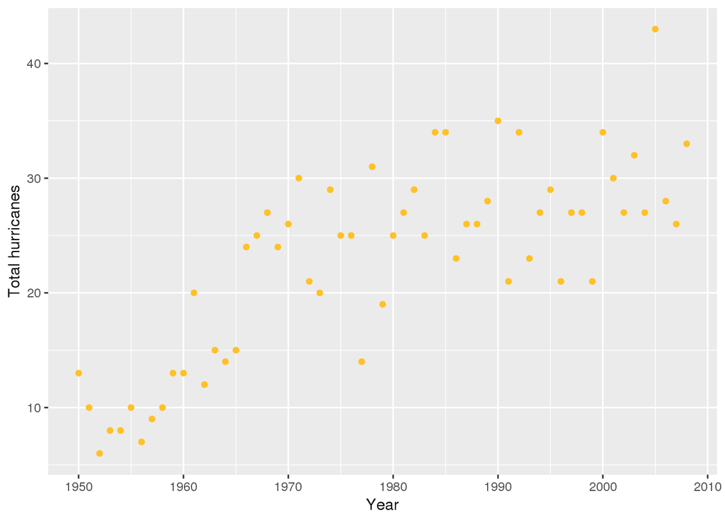

We can see that from the beginning of out data at 1950 to the end of our data in 2008, there has been a substantial increase in total number of hurricanes per year. This prompted us to ask the questions: Can we model annual hurricane frequency using CO2 concentration and NAO index as predictors?

Because we are interested in modeling the number of hurricanes per year (a count), we use a Poisson distribution. Here, $\lambda$, the parameter describing the rate at which parameters occur, describes the expected number of hurricanes per year. We use Poisson regression to model the log of the expected rate of hurricanes per year. Our model is as follows:

Let:

$Y_{t} =$ total hurricanes in year $t$

$X_{1t} =$ yearly CO2 concentration in year $t$

$X_{2t} =$ NAO index in year $t$

We propose the following model:

$$Y_t | \beta_{0}, \beta_{1}, \beta_{2} \sim Pois(\lambda_i)$$

$$log(\lambda_i) = \beta_0 + \beta_{1}X_{1t} + \beta_{2}X_{2t}$$

$$\beta_0 \sim N(0, 1e6)$$

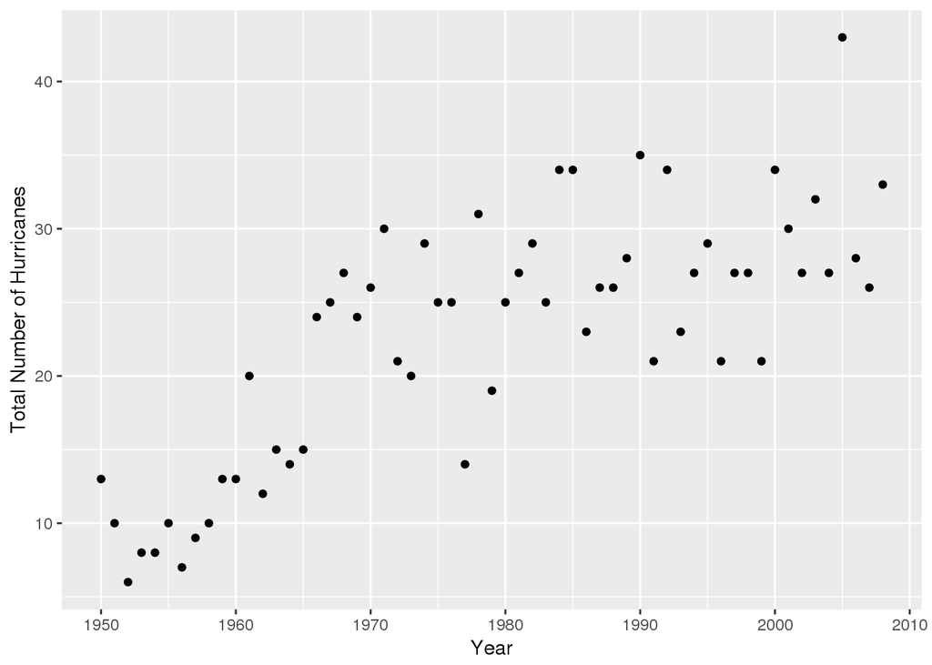

```
## List of 4
##  $ TOTAL_H: int [1:29] 25 27 29 25 34 34 23 26 26 28 ...
##  $ temp   : num [1:29] 0.17 0.39 0.06 0.26 0.04 0 0.13 0.27 0.38 0.29 ...
##  $ avg_CO2: num [1:29] 339 340 341 342 344 ...
##  $ avg_NAO: num [1:29] -0.5667 -0.1833 0.7 0.0167 0.525 ...
```

```
##    step    beta0        beta1        beta2
## 1     1 2.904685 0.0011076105 -0.078071980
## 2     2 2.970344 0.0010996416  0.045013012
## 3     3 2.946033 0.0010545876 -0.057266001
## 4     4 2.988425 0.0010437528 -0.024372794
## 5     5 2.989193 0.0009323582  0.008335066
## 6     6 3.028908 0.0010281673  0.037499344
## 7     7 3.003477 0.0009767776  0.009071462
## 8     8 2.944658 0.0010318678 -0.058651609
## 9     9 2.983145 0.0010619482  0.044308083
## 10   10 2.968329 0.0009771649  0.027601339
```

We run rjags for 5000 iterations. To confirm that our parameter estimates have converged, we create running mean plots.

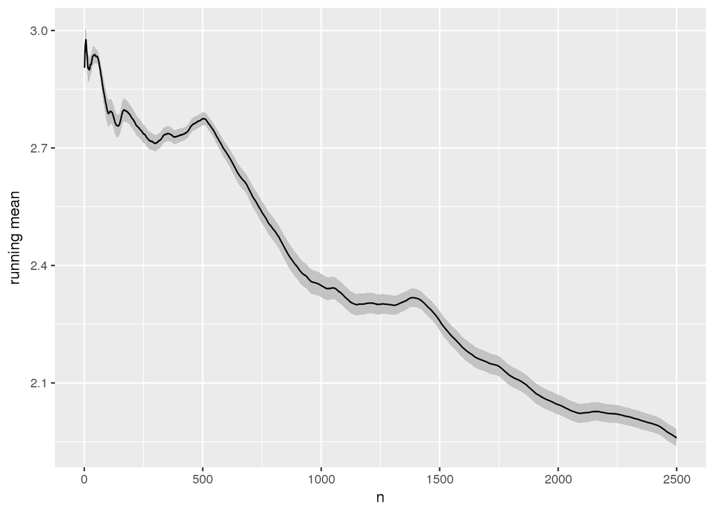

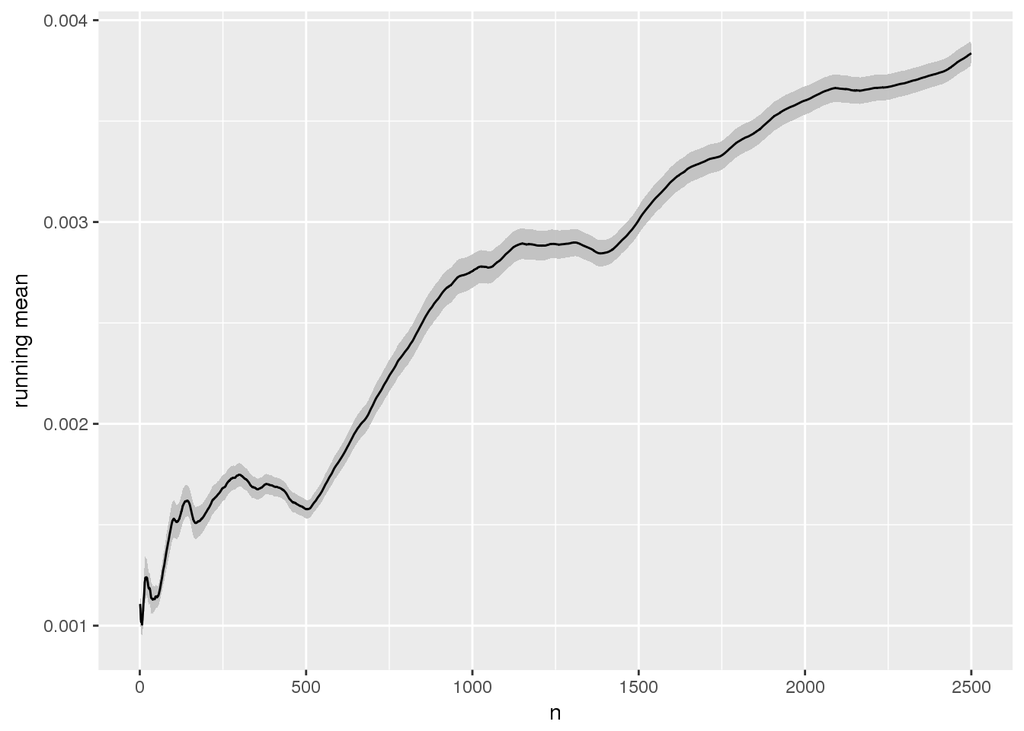

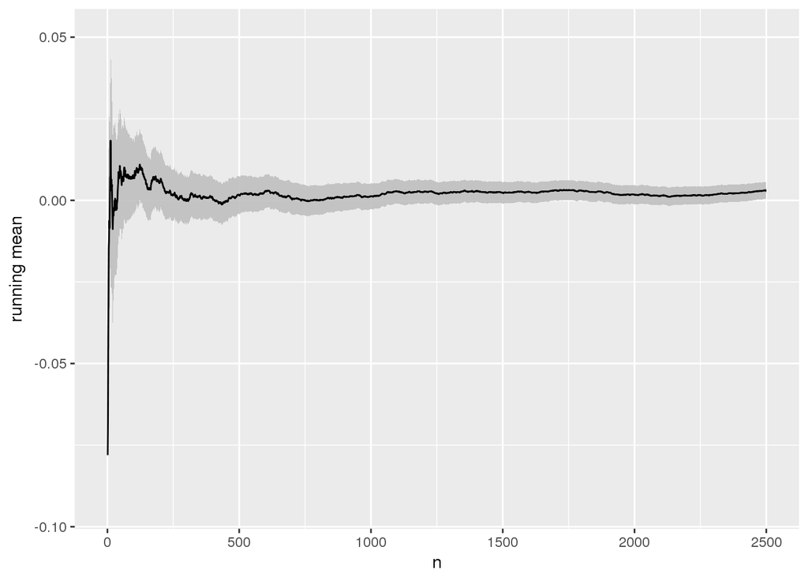

We can also visualize the posterior distributions for these estimate parameters ($\beta_0, \beta_1, \beta_2$) in trace and density plots.

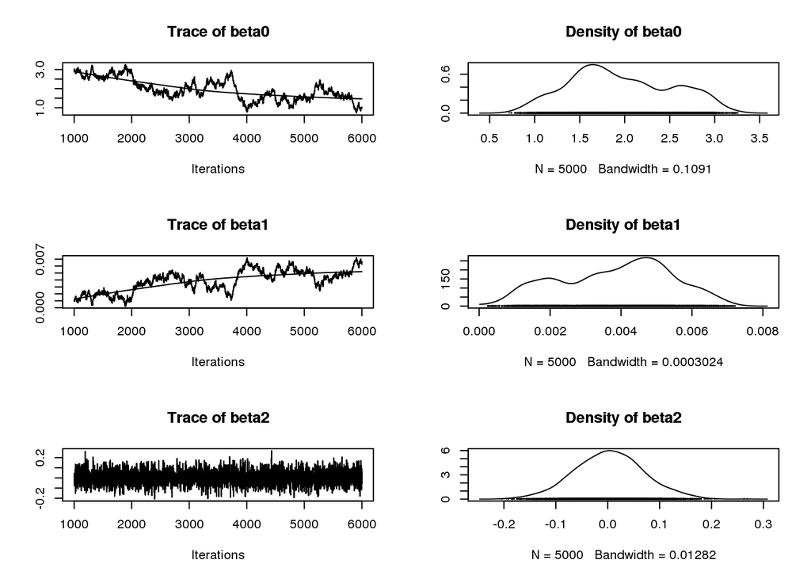

```
## [1] 0
```

```
## [1] 0.5172
```

To start, we chose to restrict this model to hurricane occurring in the Atlantic ocean. We divide our data into four zones based on latitude: equator to 24N, 24N to 44N, 44N to 64N, and 64N to 90N. We selected these zones to match zones used in the available data on temperature anomalies.

```
##   year    zone  temp
## 1 1950 N64to90 -0.02
## 2 1951 N64to90 -0.03
## 3 1952 N64to90  0.11
## 4 1953 N64to90  0.81
## 5 1954 N64to90  0.51
## 6 1955 N64to90 -0.45
```

```
##   year     zone  temp total
## 1 1950  N64to90 -0.02     0
## 2 1950  N44to64 -0.32    20
## 3 1950  N24to44  0.03   237
## 4 1950 EQUtoN24 -0.30   165
## 5 1951  N64to90 -0.03     0
## 6 1951  N44to64  0.03     7
```

Again, because we are modeling hurricane counts (although this time by zone), we use Poisson regression. Zone is included as a categorical variable of four levels. Our model is described below:

Let:

$Y_{t} =$ total hurricanes in year $t$

$X_{1t} =$ temperature anomaly by year $t$

$X_{2t} =$ zone $t$

We propose the following model:

$$Y_t | \beta_{0}, \beta_{1}, \beta_{2} \sim Pois(\lambda_i)$$

$$log(\lambda_i) = \beta_0 + \beta_{1}X_{1t} + \beta_{2}X_{2t}$$

Again, we used rjags MCMC method to estimate parameter values. Although theoretically parameter value estimates should always converge given enough iterations, parameter estimates in our model failed to converge completely after 2.5 million iterations. Due to this limitation, it should be noted that our posterior estimation is not as exact as desired.

### Hurricane Duration

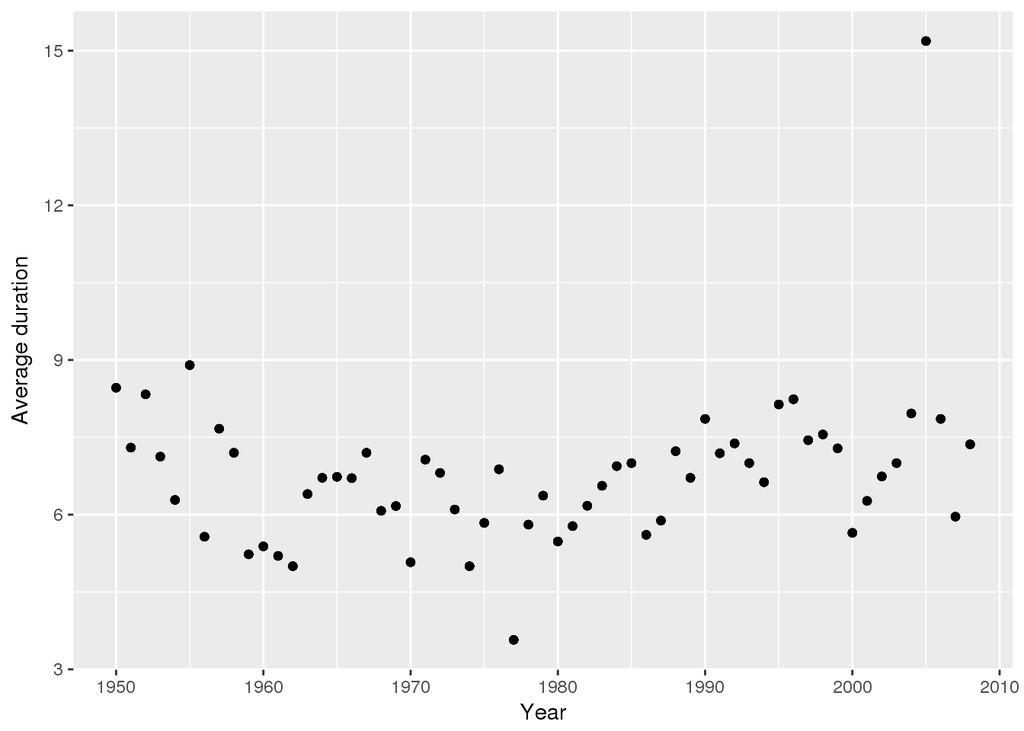

In order to model average duration of hurricanes, we decided to use normal-normal model, just like the hurricane wind speed model, but using zone categories and temperature anomalies instead of the NAO index and CO2 concentration.

$$Y_t \sim N(\beta_0+\beta_1X_{1t}+\beta_2(X_{2t}), \tau^{-1})$$
$$\beta_0\sim N(0, 100^2)$$
$$\beta_1\sim N(0, 100^2)$$
$$\beta_2\sim N(0, 100^2)$$
$$\tau\sim \Gamma(0.001, 0.001)$$

$\beta_1$ represented the coefficient for average temperature anomaly per year and $\beta_2$ represented the category zones.

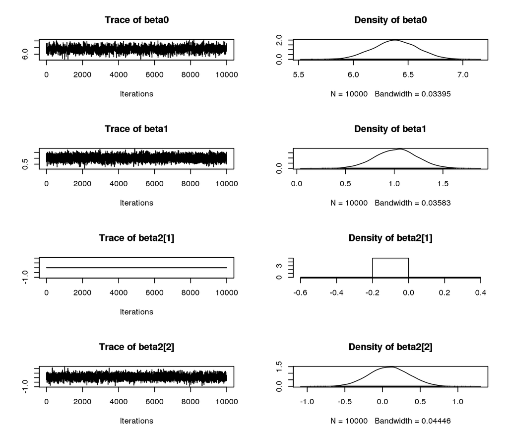

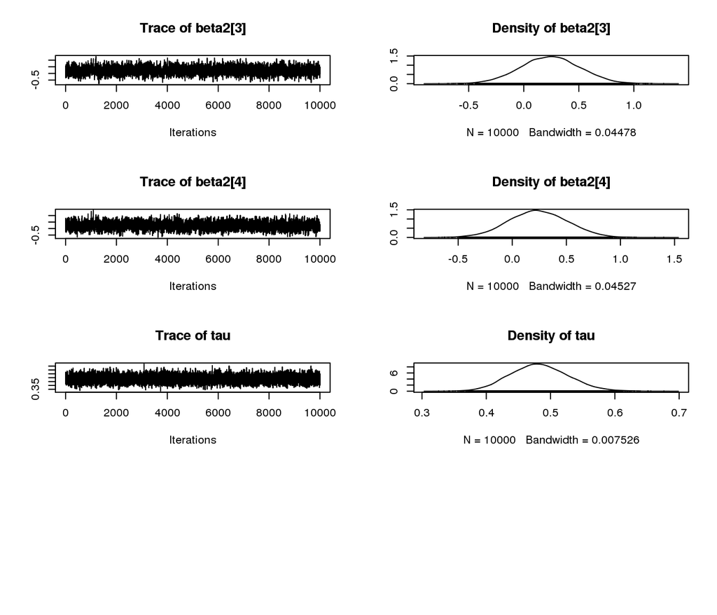

The density plots showed that the duration at the zone between latitudes 64N and 90N (shown as beta2.1.) is represented by the intercept, $\beta_0$. The other density plots show the differences from the sampled value from the intercept value. beta2.2. is the zone between 44N and 64N, beta2.3. Is the zone between 24N and 44N and the zone between the equator and 24N is represented by beta2.4.

In order to see if they converge around we looked at running mean plots.

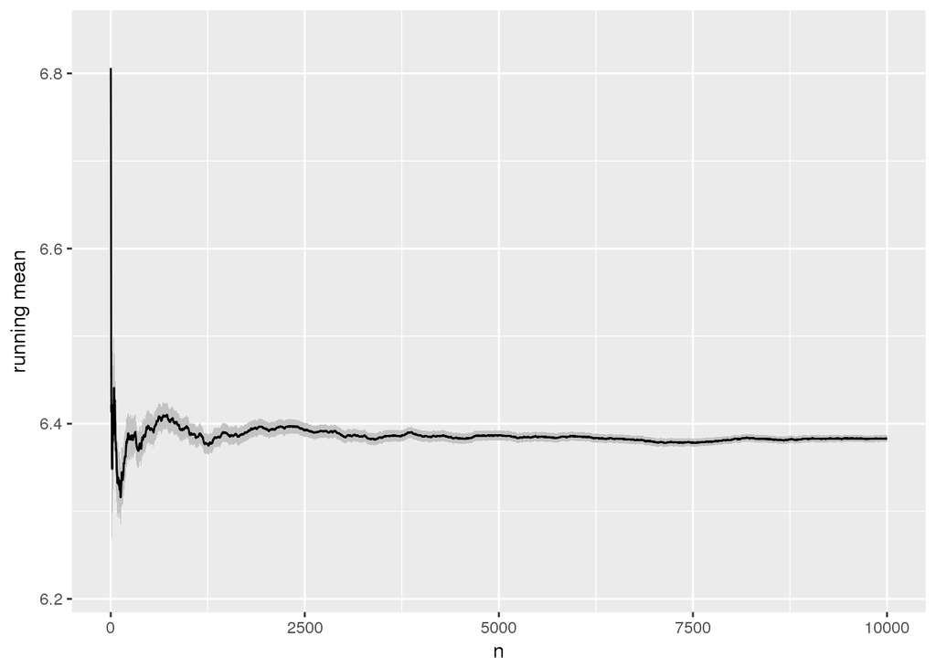

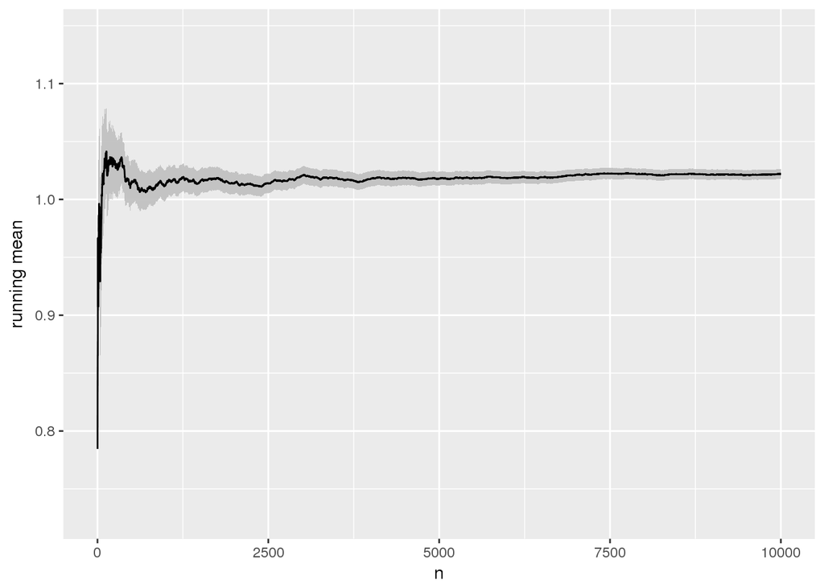

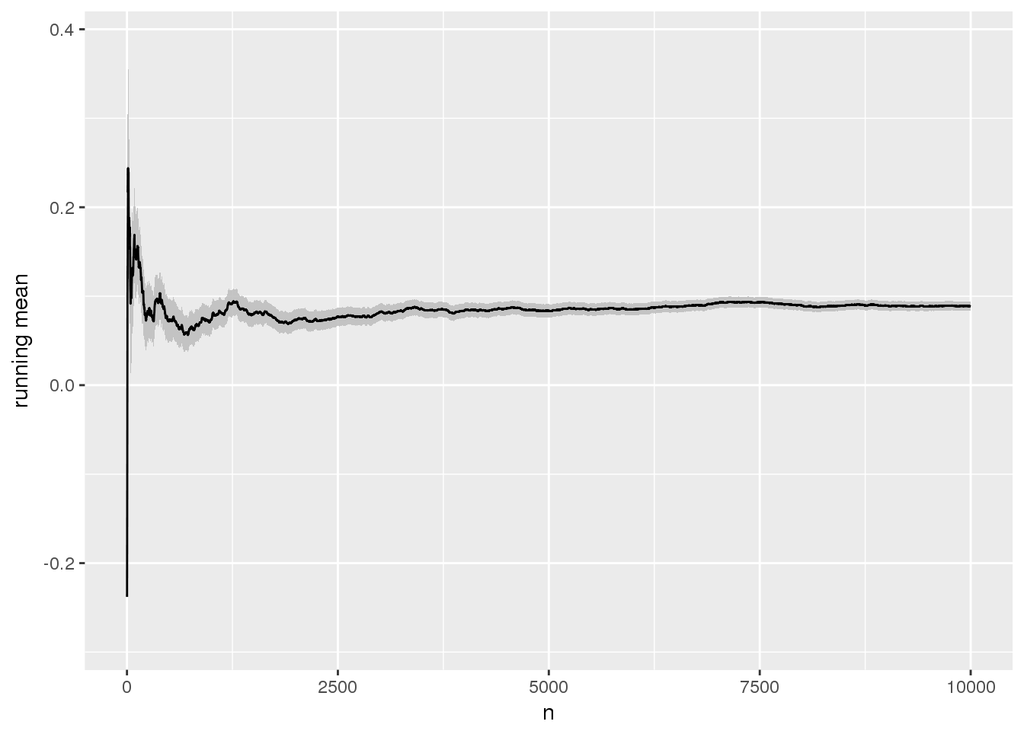

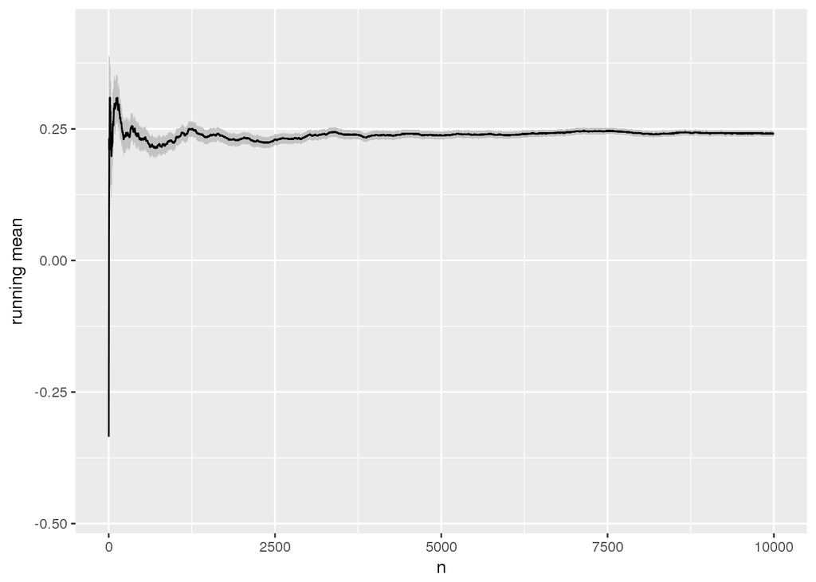

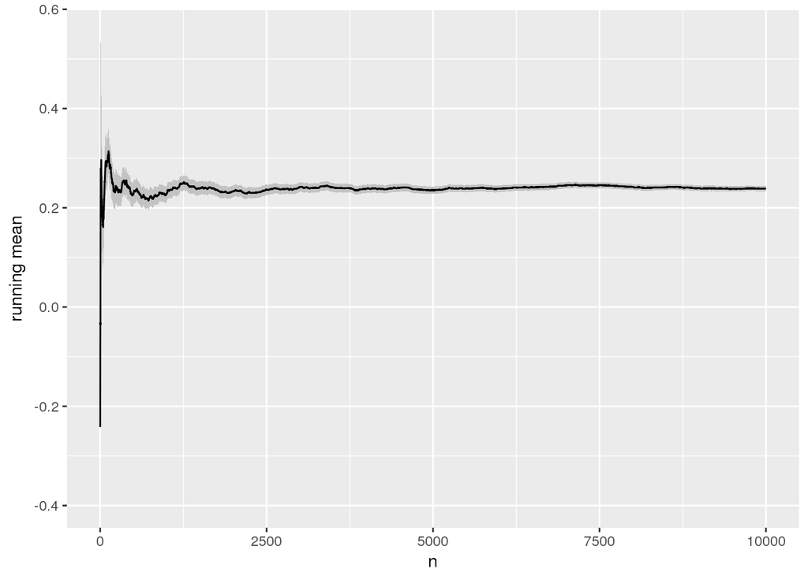

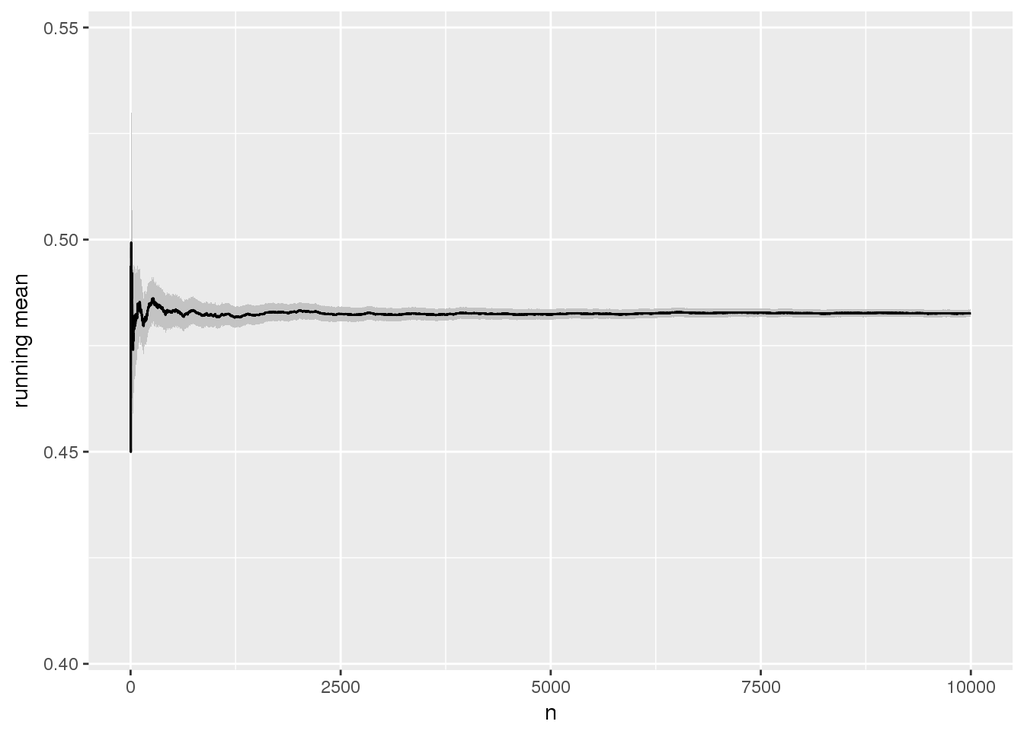

## Limitations and Future Research

Some limitations of these models is that they look at averages of the climate change variables. Therefore, even if a hurricane occurred in March, it would be modeled with climate change variables averaged using all the different months. Also, the locations we used were used in the temperature data and may or may not have been strongly correlated to the hurricanes.

Future Research we can look at is to allow for the interactions between zones and climate change variables. We can also look at hurricanes at only specific points of their path such as landfall.

## References

- *Martyn Plummer (2016). rjags: Bayesian Graphical Models using MCMC. R package version 4-6. https://CRAN.R-project.org/package=rjags

## Appendix

### Packages used

```r
library(readr)
library(dplyr)
library(tidyr)
library(ggplot2)
library(zoo)
library(lubridate)
library(ggmap)
library(reshape2)
library(MASS)
library(viridis)
library(rjags)
library(MacBayes)
```

### Data Cleaning

```r
# Loading the Data
hurricane_data <- read_csv("Historical_Tropical_Storm_Tracks.csv")
hurricane_data<-na.omit(hurricane_data)
hurricane_data<-subset(hurricane_data, select=-c(BTID, AD_TIME))

# Recent Hurricanes--select only hurricanes in 1950 and after
recent_hurricanes <- hurricane_data[hurricane_data$YEAR >= 1950, ]
recent_hurricanes <- recent_hurricanes[!(recent_hurricanes$NAME=="NOTNAMED"),]

# Hurricane Frequency
# table of hurricanes per year
hurricanes_per_year <- recent_hurricanes %>%
  group_by(YEAR) %>%
  summarise(TOTAL_H = n_distinct(NAME))
hurricanes_per_basin <- recent_hurricanes %>%
  group_by(BASIN) %>%
  summarise(TOTAL_H = n_distinct(NAME, DAY))

# Temperature Data
temp_data <- read.csv("ZonAnn.csv")
temp_data[!complete.cases(temp_data),]
temp_data<-na.omit(temp_data)
temp_data<-temp_data[,-(5:15),drop=FALSE]
temp_recent <- temp_data %>%
  filter(Year > 1949)
# select only northern hemisphere temp data
tempN <- subset(temp_recent, select = c(Year, NHem))
# rename the columns
colnames(tempN) <- c("YEAR", "temp")
# join temperature to hurricanes per year table
hurricanes_per_year2 <- merge(x = hurricanes_per_year, y = tempN, by = "YEAR", all.x = TRUE)

# CO2 Data
CO2 <- read_csv("CO2.csv")
# Alter CO2 to remove unnecessary variable trend
CO2 <- subset(CO2, select = -trend)
# get average by year
CO2_yr <- CO2 %>%
  group_by(year) %>%
  summarise(avg_CO2 = mean(average))
# rename columns
colnames(CO2_yr) <- c("YEAR", "avg_CO2")
# join with hurricane per year table
hurricanes_per_year3 <- merge(x = hurricanes_per_year2, y = CO2_yr, by = "YEAR", all.x = TRUE)
# FIX THIS (bc only 1980 onward available)

# NAO Index Data
NAO_index1 <- read_csv("NAO_index_monthly.csv",
    col_types = cols(Apr = col_number(),
        Aug = col_number(), Dec = col_number(),
        Feb = col_number(), Jan = col_number(),
        Jul = col_number(), Jun = col_number(),
        Mar = col_number(), May = col_number(),
        Nov = col_number(), Oct = col_number(),
        Sep = col_number()))
NAO_index2 <- NAO_index1[, -c(14)]
NAO_index3 <- NAO_index2 %>%
  rename(year = X1) %>%
  mutate(Jul = replace(Jul, Jul < -50| Jul > 50, "")) %>%
  mutate(Aug = replace(Aug, Aug < -50| Aug > 50, "")) %>%
  mutate(Sep = replace(Sep, Sep < -50| Sep > 50, "")) %>%
  mutate(Oct = replace(Oct, Oct < -50| Oct > 50, "")) %>%
  mutate(Nov = replace(Nov, Nov < -50| Nov > 50, "")) %>%
  mutate(Dec = replace(Dec, Dec < -50| Dec > 50, ""))
NAO_index <- NAO_index3[-nrow(NAO_index3),]
# remove 2017 (data for year is incomplete)
NAO_index <- head(NAO_index, -1)
# reshape table
NAO_index <- melt(NAO_index, id=c("year"))
colnames(NAO_index)[2] <- "month"
colnames(NAO_index)[3] <- "index"
NAO_index$year <- as.factor(NAO_index$year)
NAO_index$index <- as.numeric(NAO_index$index)
# group by year
NAO_yr <- NAO_index %>%
  group_by(year) %>%
  summarise(avg_NAO = mean(index))
# rename columns
colnames(NAO_yr) <- c("YEAR", "avg_NAO")
# join with hurricane data
hurricanes_per_year4 <- merge(x = hurricanes_per_year3, y = NAO_yr, by = "YEAR", all.x = TRUE)

# Remove all rows with missing data
hurricanes_per_year_clean<-na.omit(hurricanes_per_year4)

# Wind speed data
# Create new data set with wind speed and year
windspeed_yr <- hurricane_data %>%
  group_by(YEAR) %>%
  summarise(avg_windspeed = mean(WIND_KTS))

# Merge this with the other data set
hurricanes_per_year_clean <- merge(x = hurricanes_per_year_clean, y = windspeed_yr, by = "YEAR", all.x = TRUE)

head(hurricanes_per_year_clean)
```

### Markov Chain for Wind speed

```r
# specify the model
windSpeed_model <- "model{
    #Data
    for(i in 1:length(y)) {
        y[i] ~ dnorm(beta0 + beta1*x1[i] + beta2*x2[i], tau)

    }
    #Priors
    beta0 ~ dnorm(0, 1/(1000)^2) #PRECISION
    beta1 ~ dnorm(0, 1/(1000)^2) #PRECISION
    beta2 ~ dnorm(0, 1/(1000)^2) #PRECISION
    tau ~ dgamma(0.001, 0.001)

}"

#*set up an algorithm to simulate the posterior by
#*combining the model (games_model) and data (x)
#*set the random number seed
windSpeed_jags <- jags.model(textConnection(windSpeed_model),data=list(y=HURRICANES$avg_windspeed,x1=HURRICANES$avg_CO2,x2=HURRICANES$avg_NAO), inits = list(beta0 = 5, beta1 = 0, beta2 = 0))

#*simulate a sample from the posterior
#*note that we specify both mu and tau variables
windSpeed_sim <- coda.samples(windSpeed_jags, variable.names=c("beta0","beta1","beta2"), n.iter=500000)


#*store the samples in a data frame:
windSpeed_sample <- data.frame(step=1:500000, windSpeed_sim[[1]])
```

### Markov Chains for Frequency

#### Creating dataset for frequency, temperature, and zones

```r
# Adding zones to the temperature data and limiting time interval to between 1950-2008.
temp_data_orig<-na.omit(temp_data_orig) %>%
  filter(1950 <= Year) %>%
  filter(Year <= 2008)
my_temp <- subset(temp_data_orig, select = c("Year", "X64N.90N", "X44N.64N", "X24N.44N", "EQU.24N"))
colnames(my_temp) <- c("Year", "N64to90", "N44to64", "N24to44", "EQUtoN24")
my_temp <- melt(my_temp, id=c("Year"))
colnames(my_temp) <- c("year", "zone", "temp")

hurricane_locations_Atlantic <- merge(hurricane_locations, recent_hurricanes, by.x = c("name", "year", "lat", "long"), by.y = c("NAME", "YEAR", "LAT", "LONG"), all.x = TRUE) %>%
  filter(BASIN == "North Atlantic") %>%
  dplyr::select(c(year, name, long, lat))

hurricanes_zones <- hurricane_locations_Atlantic %>%
  mutate(zone=cut(lat, breaks=c(0, 24, 44, 64, 90), labels=c("EQUtoN24", "N24to44", "N44to64", "N64to90"))) %>%
  group_by(year, zone)  %>%
  summarise(total = n())



# Combine the  hurricane and temperature dataset together
hurricanes_per_zone <- merge(my_temp, hurricanes_zones, by = c("year", "zone"), all.x = TRUE, all.y = TRUE)
hurricanes_per_zone[is.na(hurricanes_per_zone)] <- 0
```

#### Using CO2 and NAOI

```r
head(hurricanes_per_year_clean)

hur_mod <- " model {
  for (i in 1:length(TOTAL_H)) {
      TOTAL_H[i] ~ dpois(lam[i])
      log(lam[i]) = beta0 + beta1*X1[i] + beta2*X2[i]
  }

  beta0 ~ dnorm(0.0, 1.0/1e6)
  beta1 ~ dnorm(0.0, 1.0/1e4)
  beta2 ~ dnorm(0.0, 1.0/1e4)
} "

# set up an algorithm to simulate the posterior by combining the model and data (x)
# set the random number seed

data_jags = as.list(hurricanes_per_year_clean[,2:5])
str(data_jags)

#freq_jags <- jags.model(textConnection(hur_mod),data=list(TOTAL_H = hurricanes_per_year_clean$TOTAL_H, X1 = hurricanes_per_year_clean$temp, X2 = hurricanes_per_year_clean$avg_CO2,X3 = hurricanes_per_year_clean$avg_NAO), inits=list(.RNG.name="base::Wichmann-Hill", .RNG.seed=2000))

# manually initialize parameters
freq_jags <- jags.model(textConnection(hur_mod),data=list(TOTAL_H = hurricanes_per_year_clean$TOTAL_H, X1 = hurricanes_per_year_clean$avg_CO2,X2 = hurricanes_per_year_clean$avg_NAO), inits=list(beta0=5,beta1=0, beta2=0))

# simulate a sample from the posterior
# note that we specify both mu and tau variables
freq_sim <- coda.samples(freq_jags, variable.names = c("beta0", "beta1", "beta2"), n.iter=500000)

# store the samples in a data frame:
freq_sample <- data.frame(step = 1:500000, freq_sim[[1]])
head(freq_sample, 10)


# make a dataframe of parameter values every other step to make plotting faster
Nth.delete<-function(dataframe, n)dataframe[-(seq(n,to=nrow(dataframe),by=n)),]
freq_sample_small <- Nth.delete(freq_sample, 2)
```

#### Using Temperature and Zone categories

Poisson regression–with temperature and location zone

```r
hur_mod3 <- " model {
  for (i in 1:length(total)) {
      total[i] ~ dpois(lam[i])
      log(lam[i]) = beta0 + beta1*X1[i] + beta2[X2[i]]
  }

  beta0 ~ dnorm(0.0, 1.0/1e4)
  beta1 ~ dnorm(0.0, 1.0/1e4)
  beta2[1] <- 0
  for (i in 2:4) {
    beta2[i] ~ dnorm(0.0, 1.0/1e4)
  }
} "

# set up an algorithm to simulate the posterior by combining the model and data (x)
# set the random number seed
#freq_jags3 <- jags.model(textConnection(hur_mod3),data=list(total = train_zone$total, X1 = train_zone$temp, X2 = train_zone$zone), inits=list(.RNG.name="base::Wichmann-Hill", .RNG.seed=2000))

# try to manuall initialize params
freq_jags3 <- jags.model(textConnection(hur_mod3),data=list(total = train_zone$total, X1 = train_zone$temp, X2 = train_zone$zone), inits=list(beta0=0, beta1=0, beta2 = c(NA, 8, 10, 10)))


# simulate a sample from the posterior
freq_sim3 <- coda.samples(freq_jags3, variable.names = c("beta0", "beta1", "beta2"), n.iter=2500000)

# store the samples in a data frame:
freq_sample3 <- data.frame(step = 1:2500000, freq_sim3[[1]])
head(freq_sample3, 10)
plot(freq_sim3)

freq_sample3_small <- Nth.delete(freq_sample3, 2)

plot_freq_sample3 <- freq_sample3 %>%
  filter(step > (2500000-100000))
```

Check for convergence

```r
running_mean_plot(x=plot_freq_sample3$beta2.1., se=TRUE)
running_mean_plot(x=plot_freq_sample3$beta2.2., se=TRUE)
running_mean_plot(x=plot_freq_sample3$beta2.3., se=TRUE)
running_mean_plot(x=plot_freq_sample3$beta2.4., se=TRUE)
```

### Markov Chain for Average Duration

#### Creating a new dataset with duration, zones, and temperature

```r
# Hurricane data only looking at Date and name
hurricane_time<-subset(recent_hurricanes, select = c(NAME,YEAR,MONTH,DAY))

#Group data by year and name and subtracting starting time from end time for each hurricane (duration)
foo <- hurricane_time %>%
  group_by(YEAR, NAME) %>%
  mutate(date = as.Date(paste(YEAR, MONTH, DAY, sep='-')), "%Y-%m-%d") %>%
  summarise(duration = max(date) - min(date))

#removed outlier
foo<-foo[!(foo$YEAR==1954 & foo$NAME=="ALICE"),]

# Averaging duration per year
foo<-group_by(foo, YEAR)%>%
  summarise(mean(duration))
# Name second column of data as Average_Duration
colnames(foo)[2] <- "duration"
colnames(foo)[1]<-"year"
#create durations with temperature data, CO2 data, NAOI data and frequency data
durations <- merge(foo, hurricanes_per_zone, by = c("year"), all.x = TRUE, all.y = TRUE)
```

#### Running the model

```r
library(rjags)

#specify the model
duration_model <- "model{
    #Data
    for(i in 1:length(y)) {
        y[i] ~ dnorm(beta0 + beta1*X1[i] + beta2[X2[i]],tau)
    }

    #Priors
    beta0 ~ dnorm(0.0, 1.0/1e4)
    beta1 ~ dnorm(0.0, 1.0/1e4)
    beta2[1] <- 0
    for (i in 2:4) {
      beta2[i] ~ dnorm(0.0, 1.0/1e4)
  }
    tau ~ dgamma(.001, .001)
}"

duration_jags <- jags.model(textConnection(duration_model), data=list(y = durations$duration, X1 = durations$temp, X2 = durations$zone), inits=list(.RNG.name="base::Wichmann-Hill", .RNG.seed=1989))

duration_sim <- coda.samples(duration_jags, variable.names=c("beta0","beta1", "beta2","tau"), n.iter=10000)

duration_samples <- data.frame(duration_sim[[1]])
summary(duration_sim)
plot(duration_sim)
```

```r
# running mean plot for each values
running_mean_plot(x=duration_samples$beta0, se=TRUE)
running_mean_plot(x=duration_samples$beta1, se=TRUE)

running_mean_plot(x=duration_samples$beta2.2., se=TRUE)
running_mean_plot(x=duration_samples$beta2.3., se=TRUE)
running_mean_plot(x=duration_samples$beta2.4., se=TRUE)
running_mean_plot(x=duration_samples$tau, se=TRUE)
```

```r
set.seed(19)

# 95% conidence interval
quantile(duration_samples$beta0, c(0.05, 0.975))
quantile(duration_samples$beta1, c(0.05, 0.975))
quantile(duration_samples$beta2.1.+duration_samples$beta0, c(0.05, 0.975))
quantile(duration_samples$beta2.2.+duration_samples$beta0, c(0.05, 0.975))
quantile(duration_samples$beta2.3.+duration_samples$beta0, c(0.05, 0.975))
quantile(duration_samples$beta2.4.+duration_samples$beta0, c(0.05, 0.975))

# Mean of all parameters
mean(duration_samples$beta0)
mean(duration_samples$beta1)
mean(duration_samples$beta2.1.+duration_samples$beta0)
mean(duration_samples$beta2.2.+duration_samples$beta0)
mean(duration_samples$beta2.3.+duration_samples$beta0)
mean(duration_samples$beta2.4.+duration_samples$beta0)
mean(duration_samples$tau)

# Posterior probability
mean(duration_samples$beta2.2.<0)
mean(duration_samples$beta2.3.<0)
mean(duration_samples$beta2.4.<0)
```